# HackerOne Bug Bounty Dataset — Exploratory Data Analysis

**Dataset:** `okweh1` — Publicly disclosed HackerOne vulnerability reports (2014–2025)  
**Records:** 6,876 JSON files organised in year-based sub-folders  
**Goal:** Load, clean, analyse and visualise the dataset to uncover patterns in the bug-bounty ecosystem.

1. Environment Setup
2. Data Loading
3. Data Cleaning & Feature Engineering
4. Exploratory Statistics
5. Visualisation — Volume & Temporal Trends
6. Visualisation — Severity Analysis
7. Visualisation — Bounty Analysis
8. Visualisation — Weakness & Program Analysis
9. Visualisation — Reporter Analysis
10. Visualisation — Disclosure & Community Engagement
11. Visualisation — Advanced / Cross-Feature Analysis
12. Save Cleaned Dataset
13. Key Findings Summary

## 1. Environment Setup

```python
# Install dependencies (uncomment if needed)
# !pip install pandas numpy matplotlib seaborn wordcloud scipy

import json, os, glob, warnings
import pandas as pd
import numpy as np
import matplotlib
import matplotlib.pyplot as plt
import matplotlib.ticker as mticker
import seaborn as sns
from collections import Counter
from wordcloud import WordCloud
from scipy import stats

warnings.filterwarnings('ignore')
%matplotlib inline

print("Libraries loaded successfully")
print(f"   pandas  {pd.__version__}")
print(f"   numpy   {np.__version__}")
print(f"   seaborn {sns.__version__}")
```

```
Libraries loaded successfully
   pandas  2.3.1
   numpy   2.3.5
   seaborn 0.13.2
```

```python
# ── Global dark theme ────────────────────────────────────────────────────────
DARK   = "#0d1117"
CARD   = "#161b22"
ACCENT = "#58a6ff"
GREEN  = "#3fb950"
RED    = "#f85149"
YELLOW = "#d29922"
PURPLE = "#bc8cff"
ORANGE = "#f0883e"
COLORS = [ACCENT, GREEN, RED, YELLOW, PURPLE, ORANGE,
          "#79c0ff", "#56d364", "#ff7b72", "#e3b341"]

SEV_ORDER  = ["none", "low", "medium", "high", "critical", "unknown"]
SEV_COLORS = {"critical": RED, "high": ORANGE, "medium": YELLOW,
              "low": GREEN, "none": ACCENT, "unknown": "#8b949e"}

plt.rcParams.update({
    "figure.facecolor": DARK, "axes.facecolor": CARD,
    "axes.edgecolor": "#30363d", "axes.labelcolor": "#e6edf3",
    "axes.titlecolor": "#e6edf3", "text.color": "#e6edf3",
    "xtick.color": "#8b949e",   "ytick.color": "#8b949e",
    "grid.color": "#21262d",    "grid.alpha": 0.6,
    "legend.facecolor": CARD,   "legend.edgecolor": "#30363d",
    "font.family": "DejaVu Sans", "font.size": 11,
})

print("Plot theme configured")
```

```
Plot theme configured
```

## 2. Data Loading

The dataset lives in `okweh1/` with one sub-folder per year (2014–2025) plus an `ALL/` directory.  
Each file is a single JSON object representing one disclosed vulnerability report.

We iterate every year folder, parse each JSON file and tag it with its year folder for later use.

```python
# ── Set the base path to your local okweh1 folder ────────────────────────────
BASE_PATH = "D:\Axiler\Week1\Dataset EDA\okweh1"   # <-- change this if your folder is elsewhere

records = []

for year_dir in sorted(glob.glob(f"{BASE_PATH}/[0-9][0-9][0-9][0-9]")):
    year = os.path.basename(year_dir)
    json_files = glob.glob(f"{year_dir}/*.json")
    for fp in json_files:
        try:
            with open(fp, encoding="utf-8") as f:
                d = json.load(f)
            d["_year_folder"] = int(year)
            records.append(d)
        except Exception as e:
            print(f"  ⚠ Could not parse {fp}: {e}")

print(f"Loaded {len(records):,} records from {BASE_PATH}")
```

```
Loaded 6,876 records from D:\Axiler\Week1\Dataset EDA\okweh1
```

```python
# ── File count per year ───────────────────────────────────────────────────────
from collections import Counter

year_counts = Counter(r["_year_folder"] for r in records)
yr_df = pd.DataFrame(sorted(year_counts.items()), columns=["Year", "Files"])
yr_df["Cumulative"] = yr_df["Files"].cumsum()
print(yr_df.to_string(index=False))
```

```
 Year  Files  Cumulative
 2014      8           8
 2015     33          41
 2016    348         389
 2017    799        1188
 2018    884        2072
 2019    855        2927
 2020   1186        4113
 2021    913        5026
 2022    622        5648
 2023    444        6092
 2024    350        6442
 2025    434        6876
```

## 3. Data Cleaning & Feature Engineering

Each JSON has a rich nested structure. We extract the most analytically useful fields into a flat DataFrame, then engineer new derived columns.

### Fields extracted

| Field | Source | Notes |
| --- | --- | --- |
| `id`, `title`, `state`, `substate` | root | Core identifiers |
| `severity_rating` | `severity.rating` or root | Normalised to lowercase |
| `has_bounty`, `bounty_amount` | root | Float; NaN when no bounty |
| `vote_count`, `vuln_info_len` | root / computed | Community signal + report length |
| `created_at`, `disclosed_at` | root | Parsed as UTC datetimes |
| `reporter`, `reporter_cleared`, `reporter_verified` | `reporter` | Reporter profile |
| `team_handle`, `team_name`, `offers_bounties` | `team` | Program info |
| `weakness_name`, `weakness_id` | `weakness` | CWE-style category |
| `has_cve`, `cve_ids` | root | CVE linkage |
| `submitted_with_ai` | root | AI-assisted flag |

### Engineered features

- `created_year`, `created_month`, `created_dow` — temporal decomposition
- `disclosure_days` — time (days) between submission and public disclosure

```python
def extract_record(d):
    rep  = d.get("reporter") or {}
    team = d.get("team")    or {}
    tp   = team.get("profile") or {}
    sev  = d.get("severity") or {}
    weak = d.get("weakness") or {}

    bounty = d.get("bounty_amount")

    return {
        # ── identifiers ──────────────────────────────────────────────────────
        "id":                d.get("id"),
        "title":             d.get("title", ""),
        "state":             d.get("state", ""),
        "substate":          d.get("substate", ""),
        # ── severity ─────────────────────────────────────────────────────────
        "severity_rating":   (d.get("severity_rating") or sev.get("rating") or "unknown").lower(),
        # ── bounty ───────────────────────────────────────────────────────────
        "has_bounty":        bool(d.get("has_bounty?")),
        "bounty_amount":     float(bounty) if bounty else None,
        # ── community signal ─────────────────────────────────────────────────
        "vote_count":        d.get("vote_count", 0),
        # ── timestamps ───────────────────────────────────────────────────────
        "created_at":        pd.to_datetime(d.get("created_at"),   utc=True, errors="coerce"),
        "submitted_at":      pd.to_datetime(d.get("submitted_at"), utc=True, errors="coerce"),
        "disclosed_at":      pd.to_datetime(d.get("disclosed_at"), utc=True, errors="coerce"),
        # ── reporter ─────────────────────────────────────────────────────────
        "reporter":          rep.get("username", ""),
        "reporter_cleared":  rep.get("cleared",  False),
        "reporter_verified": rep.get("verified", False),
        # ── program / team ───────────────────────────────────────────────────
        "team_handle":       team.get("handle", ""),
        "team_name":         tp.get("name", ""),
        "offers_bounties":   team.get("offers_bounties", False),
        # ── weakness ─────────────────────────────────────────────────────────
        "weakness_name":     weak.get("name", ""),
        "weakness_id":       weak.get("id"),
        # ── CVE ──────────────────────────────────────────────────────────────
        "cve_ids":           d.get("cve_ids", []),
        "has_cve":           bool(d.get("cve_ids", [])),
        # ── misc ─────────────────────────────────────────────────────────────
        "public":            d.get("public", False),
        "submitted_with_ai": d.get("submitted_with_assistant", False),
        "vuln_info_len":     len(d.get("vulnerability_information", "") or ""),
        "_year_folder":      d.get("_year_folder"),
    }

df = pd.DataFrame([extract_record(d) for d in records])
print(f"DataFrame shape: {df.shape}")
df.head(3)
```

```
DataFrame shape: (6876, 25)
```

|  | id | title | state | substate | severity_rating | has_bounty | bounty_amount | vote_count | created_at | submitted_at | ... | team_name | offers_bounties | weakness_name | weakness_id | cve_ids | has_cve | public | submitted_with_ai | vuln_info_len | _year_folder |
| --- | --- | --- | --- | --- | --- | --- | --- | --- | --- | --- | --- | --- | --- | --- | --- | --- | --- | --- | --- | --- | --- |
| 0 | 11073 | XSS in gist integration | Closed | resolved | unknown | True | 500.0 | 156 | 2014-05-06 18:21:27.236000+00:00 | 2014-05-06 18:21:27.236000+00:00 | ... | Slack | True | Cross-site Scripting (XSS) - Generic | 60.0 | [] | False | True | False | 262 | 2014 |
| 1 | 16910 | Cross-site information assertion leak via Cont... | Closed | resolved | unknown | False | NaN | 13 | 2014-06-18 22:31:04.534000+00:00 | 2014-06-18 22:31:04.534000+00:00 | ... | Internet Bug Bounty | True | Information Disclosure | 18.0 | [] | False | True | False | 4323 | 2014 |
| 2 | 18843 | use-after-free vulnerability in Flash Player | Closed | resolved | unknown | True | NaN | 1 | 2014-07-03 05:06:17.257000+00:00 | 2014-07-03 05:06:17.257000+00:00 | ... | Internet Bug Bounty | True | Memory Corruption - Generic | 2.0 | [] | False | True | False | 6175 | 2014 |

3 rows × 25 columns

```python
# ── Temporal feature engineering ─────────────────────────────────────────────
df["created_year"]    = df["created_at"].dt.year
df["created_month"]   = df["created_at"].dt.month
df["created_dow"]     = df["created_at"].dt.day_of_week   # 0 = Monday

df["disclosure_days"] = (df["disclosed_at"] - df["submitted_at"]).dt.days

print("New columns added: created_year, created_month, created_dow, disclosure_days")
df[["created_at", "disclosed_at", "disclosure_days"]].head(5)
```

```
New columns added: created_year, created_month, created_dow, disclosure_days
```

|  | created_at | disclosed_at | disclosure_days |
| --- | --- | --- | --- |
| 0 | 2014-05-06 18:21:27.236000+00:00 | 2019-04-28 00:11:34.790000+00:00 | 1817 |
| 1 | 2014-06-18 22:31:04.534000+00:00 | 2018-09-05 02:23:54.114000+00:00 | 1539 |
| 2 | 2014-07-03 05:06:17.257000+00:00 | 2019-11-12 09:44:13.020000+00:00 | 1958 |
| 3 | 2014-02-25 07:08:24.808000+00:00 | 2019-11-12 23:47:52.177000+00:00 | 2086 |
| 4 | 2014-08-21 18:21:11.762000+00:00 | 2019-10-14 08:48:43.922000+00:00 | 1879 |

## 4. Exploratory Statistics

Before plotting, we examine basic descriptive statistics, null rates, data types and value distributions.

```python
# ── Data types & null rates ───────────────────────────────────────────────────
# Convert list-type columns to strings first so nunique() can hash them
df_hashable = df.copy()
for col in df_hashable.columns:
    if df_hashable[col].apply(lambda x: isinstance(x, list)).any():
        df_hashable[col] = df_hashable[col].apply(
            lambda x: ";".join(x) if isinstance(x, list) else x)

null_info = pd.DataFrame({
    "dtype":      df.dtypes,
    "null_count": df.isnull().sum(),
    "null_%":     (df.isnull().mean() * 100).round(2),
    "unique":     df_hashable.nunique(),
})
null_info
```

|  | dtype | null_count | null_% | unique |
| --- | --- | --- | --- | --- |
| id | int64 | 0 | 0.00 | 6876 |
| title | object | 0 | 0.00 | 6707 |
| state | object | 0 | 0.00 | 1 |
| substate | object | 0 | 0.00 | 5 |
| severity_rating | object | 0 | 0.00 | 6 |
| has_bounty | bool | 0 | 0.00 | 2 |
| bounty_amount | float64 | 5589 | 81.28 | 149 |
| vote_count | int64 | 0 | 0.00 | 335 |
| created_at | datetime64[ns, UTC] | 0 | 0.00 | 6876 |
| submitted_at | datetime64[ns, UTC] | 0 | 0.00 | 6876 |
| disclosed_at | datetime64[ns, UTC] | 0 | 0.00 | 6874 |
| reporter | object | 0 | 0.00 | 3233 |
| reporter_cleared | bool | 0 | 0.00 | 2 |
| reporter_verified | bool | 0 | 0.00 | 2 |
| team_handle | object | 0 | 0.00 | 267 |
| team_name | object | 0 | 0.00 | 267 |
| offers_bounties | bool | 0 | 0.00 | 2 |
| weakness_name | object | 0 | 0.00 | 173 |
| weakness_id | float64 | 655 | 9.53 | 173 |
| cve_ids | object | 0 | 0.00 | 1173 |
| has_cve | bool | 0 | 0.00 | 2 |
| public | bool | 0 | 0.00 | 1 |
| submitted_with_ai | bool | 0 | 0.00 | 2 |
| vuln_info_len | int64 | 0 | 0.00 | 3645 |
| _year_folder | int64 | 0 | 0.00 | 12 |
| created_year | int32 | 0 | 0.00 | 13 |
| created_month | int32 | 0 | 0.00 | 12 |
| created_dow | int32 | 0 | 0.00 | 7 |
| disclosure_days | int64 | 0 | 0.00 | 1049 |

```python
# ── Numeric summary ───────────────────────────────────────────────────────────
num_cols = ["vote_count", "vuln_info_len", "disclosure_days", "bounty_amount"]
df[num_cols].describe().round(2)
```

|  | vote_count | vuln_info_len | disclosure_days | bounty_amount |
| --- | --- | --- | --- | --- |
| count | 6876.00 | 6876.00 | 6876.00 | 1287.00 |
| mean | 36.99 | 2484.56 | 233.19 | 1681.91 |
| std | 88.80 | 4233.01 | 364.08 | 3396.57 |
| min | 0.00 | 7.00 | 0.00 | 25.00 |
| 25% | 6.00 | 822.00 | 27.00 | 300.00 |
| 50% | 15.00 | 1505.00 | 81.00 | 500.00 |
| 75% | 36.00 | 2691.25 | 261.00 | 2000.00 |
| max | 2974.00 | 84544.00 | 3331.00 | 50000.00 |

```python
# ── Categorical value counts ──────────────────────────────────────────────────
print("── state ──────────────────────────────")
print(df["state"].value_counts().to_string())

print("\n── substate ────────────────────────────")
print(df["substate"].value_counts().to_string())

print("\n── severity_rating ─────────────────────")
print(df["severity_rating"].value_counts().to_string())
```

```
── state ──────────────────────────────
state
Closed    6876

── substate ────────────────────────────
substate
resolved          5683
informative        605
not-applicable     386
duplicate          175
spam                27

── severity_rating ─────────────────────
severity_rating
medium      2396
low         1433
high        1259
unknown      760
critical     674
none         354
```

```python
# ── Boolean flags summary ────────────────────────────────────────────────────
bool_cols = ["has_bounty", "has_cve", "public", "submitted_with_ai",
             "reporter_cleared", "reporter_verified", "offers_bounties"]
bool_summary = pd.DataFrame({
    "True":  df[bool_cols].sum(),
    "False": (~df[bool_cols]).sum(),
    "True%": (df[bool_cols].mean() * 100).round(2),
})
bool_summary
```

|  | True | False | True% |
| --- | --- | --- | --- |
| has_bounty | 2986 | 3890 | 43.43 |
| has_cve | 1357 | 5519 | 19.74 |
| public | 6876 | 0 | 100.00 |
| submitted_with_ai | 8 | 6868 | 0.12 |
| reporter_cleared | 1195 | 5681 | 17.38 |
| reporter_verified | 2131 | 4745 | 30.99 |
| offers_bounties | 4919 | 1957 | 71.54 |

## 5. Visualisation — Volume & Temporal Trends

Understanding *when* reports are filed reveals platform growth, researcher behaviour and seasonal patterns.

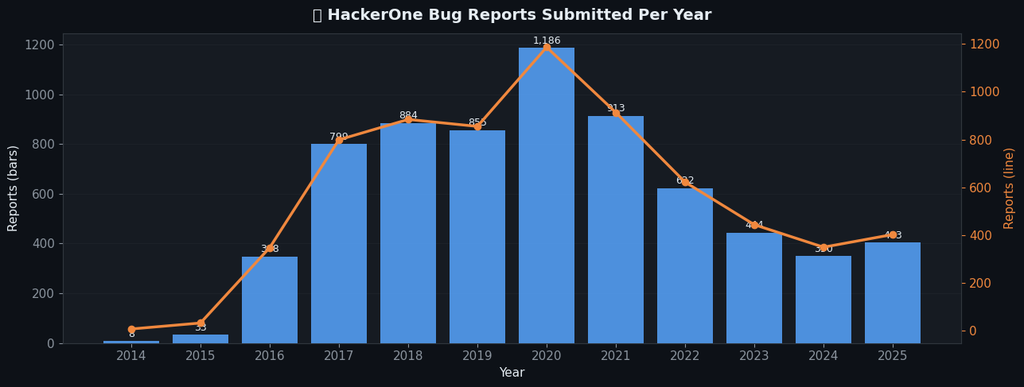

```python
# ── Plot 1 · Reports per year (bar + trend line) ─────────────────────────────
yr = df[df["created_year"].between(2014, 2025)].groupby("created_year").size()

fig, ax = plt.subplots(figsize=(13, 5))
bars = ax.bar(yr.index, yr.values, color=ACCENT, alpha=0.85, zorder=3)
ax2  = ax.twinx()
ax2.plot(yr.index, yr.values, color=ORANGE, lw=2.5, marker="o", ms=6, zorder=4)
ax2.set_ylabel("Reports (line)", color=ORANGE)
ax2.tick_params(axis="y", colors=ORANGE)
ax2.set_facecolor(CARD)

for b in bars:
    ax.text(b.get_x() + b.get_width()/2, b.get_height() + 8,
            f"{int(b.get_height()):,}", ha="center", va="bottom",
            fontsize=9, color="#e6edf3")

ax.set_xlabel("Year"); ax.set_ylabel("Reports (bars)")
ax.set_title("📊 HackerOne Bug Reports Submitted Per Year", fontsize=14,
             fontweight="bold", pad=12)
ax.grid(axis="y", zorder=0); ax.set_xticks(yr.index)
plt.tight_layout(); plt.show()
```

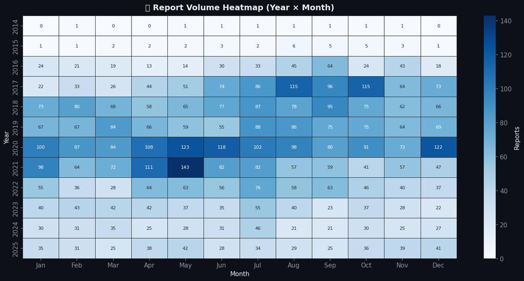

```python
# ── Plot 2 · Monthly heatmap (Year × Month) ──────────────────────────────────
heat = (df[df["created_year"].between(2014, 2025)]
        .groupby(["created_year", "created_month"])
        .size()
        .unstack(fill_value=0))

fig, ax = plt.subplots(figsize=(14, 7))
sns.heatmap(heat, ax=ax, cmap="Blues", linewidths=0.4, linecolor="#21262d",
            cbar_kws={"label": "Reports"}, annot=True, fmt="d",
            annot_kws={"size": 8})
ax.set_xlabel("Month"); ax.set_ylabel("Year")
ax.set_xticklabels(["Jan","Feb","Mar","Apr","May","Jun",
                    "Jul","Aug","Sep","Oct","Nov","Dec"])
ax.set_title("📅 Report Volume Heatmap (Year × Month)", fontsize=14,
             fontweight="bold", pad=10)
plt.tight_layout(); plt.show()
```

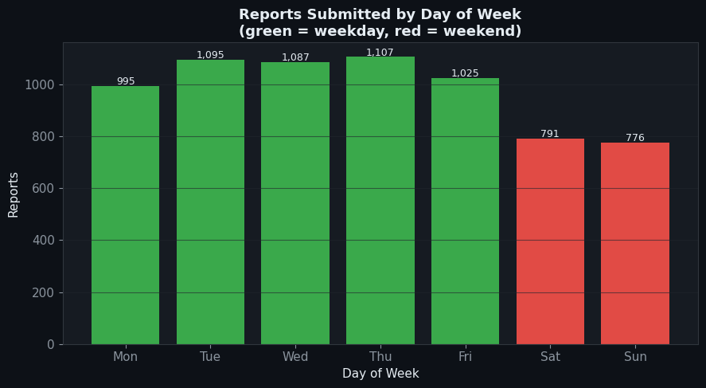

```python
# ── Plot 3 · Reports by day of week ──────────────────────────────────────────
DOW = {0:"Mon", 1:"Tue", 2:"Wed", 3:"Thu", 4:"Fri", 5:"Sat", 6:"Sun"}
dow  = df["created_dow"].map(DOW).value_counts().reindex(DOW.values())

fig, ax = plt.subplots(figsize=(9, 5))
c_dow   = [GREEN if i < 5 else RED for i in range(7)]
bars    = ax.bar(dow.index, dow.values, color=c_dow, alpha=0.9)
for b in bars:
    ax.text(b.get_x() + b.get_width()/2, b.get_height() + 5,
            f"{int(b.get_height()):,}", ha="center", fontsize=9)
ax.set_xlabel("Day of Week"); ax.set_ylabel("Reports")
ax.set_title("Reports Submitted by Day of Week\n(green = weekday, red = weekend)",
             fontsize=13, fontweight="bold")
ax.grid(axis="y"); plt.tight_layout(); plt.show()
```

## 6. Visualisation — Severity Analysis

Severity drives bounty size, urgency and public interest. We examine its distribution and evolution over time.

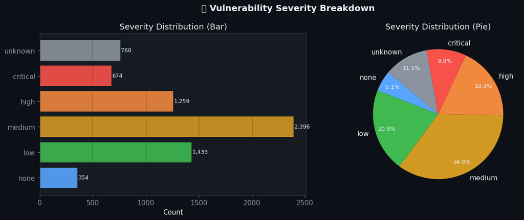

```python
# ── Plot 4 · Severity distribution (bar + pie) ───────────────────────────────
sev_counts = df["severity_rating"].fillna("unknown").value_counts()
sev_plot   = sev_counts.reindex([s for s in SEV_ORDER if s in sev_counts.index])
c_list     = [SEV_COLORS.get(s, ACCENT) for s in sev_plot.index]

fig, (ax1, ax2) = plt.subplots(1, 2, figsize=(13, 5))

bars = ax1.barh(sev_plot.index, sev_plot.values, color=c_list, alpha=0.9)
for b in bars:
    ax1.text(b.get_width() + 5, b.get_y() + b.get_height()/2,
             f"{int(b.get_width()):,}", va="center", fontsize=9)
ax1.set_xlabel("Count"); ax1.set_title("Severity Distribution (Bar)")
ax1.grid(axis="x")

wedges, texts, autotexts = ax2.pie(
    sev_plot.values, labels=sev_plot.index, colors=c_list,
    autopct="%1.1f%%", startangle=140,
    textprops={"color": "#e6edf3"}, pctdistance=0.82)
for at in autotexts:
    at.set_fontsize(9)
ax2.set_title("Severity Distribution (Pie)")

fig.suptitle("🛡️ Vulnerability Severity Breakdown", fontsize=14, fontweight="bold")
plt.tight_layout(); plt.show()
```

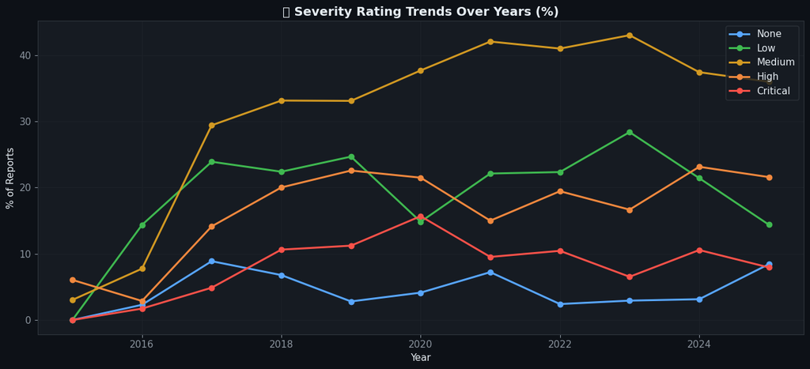

```python
# ── Plot 5 · Severity rating trends over years (%) ───────────────────────────
sev_yr = (df[df["created_year"].between(2015, 2025)]
          .groupby(["created_year", "severity_rating"])
          .size()
          .unstack(fill_value=0))

for col in SEV_ORDER:
    if col not in sev_yr:
        sev_yr[col] = 0

sev_yr_pct = sev_yr.div(sev_yr.sum(axis=1), axis=0) * 100

fig, ax = plt.subplots(figsize=(13, 6))
for sev in [s for s in SEV_ORDER if s != "unknown"]:
    if sev in sev_yr_pct:
        ax.plot(sev_yr_pct.index, sev_yr_pct[sev],
                marker="o", lw=2.2, label=sev.capitalize(),
                color=SEV_COLORS.get(sev, ACCENT))

ax.set_xlabel("Year"); ax.set_ylabel("% of Reports")
ax.set_title("📈 Severity Rating Trends Over Years (%)", fontsize=14, fontweight="bold")
ax.legend(loc="upper right"); ax.grid()
plt.tight_layout(); plt.show()
```

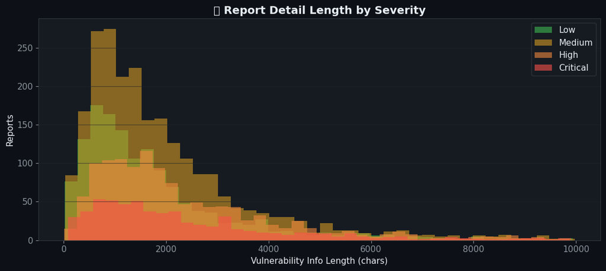

```python
# ── Plot 6 · Report detail length (chars) by severity ────────────────────────
vlen = df[df["severity_rating"].isin(["low","medium","high","critical"])].copy()
vlen = vlen[vlen["vuln_info_len"] < 10_000]

fig, ax = plt.subplots(figsize=(11, 5))
for sev in ["low", "medium", "high", "critical"]:
    sub = vlen[vlen["severity_rating"] == sev]["vuln_info_len"]
    ax.hist(sub, bins=40, alpha=0.6, label=sev.capitalize(),
            color=SEV_COLORS[sev])

ax.set_xlabel("Vulnerability Info Length (chars)")
ax.set_ylabel("Reports")
ax.set_title("📝 Report Detail Length by Severity", fontsize=14, fontweight="bold")
ax.legend(); ax.grid(axis="y")
plt.tight_layout(); plt.show()
```

## 7. Visualisation — Bounty Analysis

Bounty data tells us what the industry pays for different vulnerability types and how economic incentives are structured.

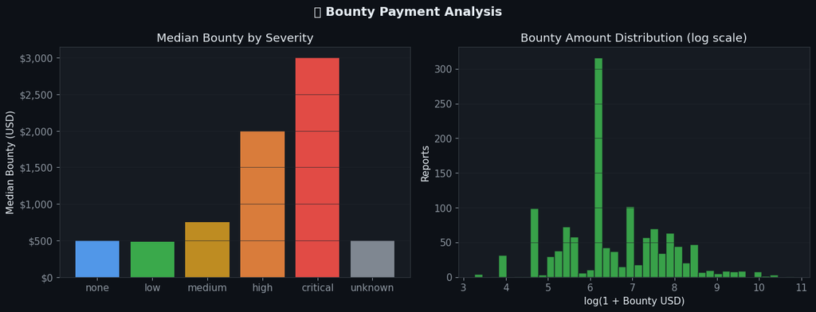

```python
# ── Plot 7 · Median bounty by severity + bounty amount distribution ──────────
bounty_df = df[df["has_bounty"] & df["bounty_amount"].notna() & (df["bounty_amount"] > 0)]
sev_bounty = (bounty_df.groupby("severity_rating")["bounty_amount"]
              .median()
              .reindex([s for s in SEV_ORDER
                        if s in bounty_df["severity_rating"].unique()]))

fig, (ax1, ax2) = plt.subplots(1, 2, figsize=(13, 5))

c2 = [SEV_COLORS.get(s, ACCENT) for s in sev_bounty.index]
ax1.bar(sev_bounty.index, sev_bounty.values, color=c2, alpha=0.9)
ax1.set_ylabel("Median Bounty (USD)")
ax1.set_title("Median Bounty by Severity")
ax1.yaxis.set_major_formatter(mticker.FuncFormatter(lambda x, _: f"${x:,.0f}"))
ax1.grid(axis="y")

bounty_df = bounty_df.copy()
bounty_df["bounty_log"] = np.log1p(bounty_df["bounty_amount"])
ax2.hist(bounty_df["bounty_log"], bins=40, color=GREEN, alpha=0.85, edgecolor=CARD)
ax2.set_xlabel("log(1 + Bounty USD)"); ax2.set_ylabel("Reports")
ax2.set_title("Bounty Amount Distribution (log scale)")
ax2.grid(axis="y")

fig.suptitle("💰 Bounty Payment Analysis", fontsize=14, fontweight="bold")
plt.tight_layout(); plt.show()
```

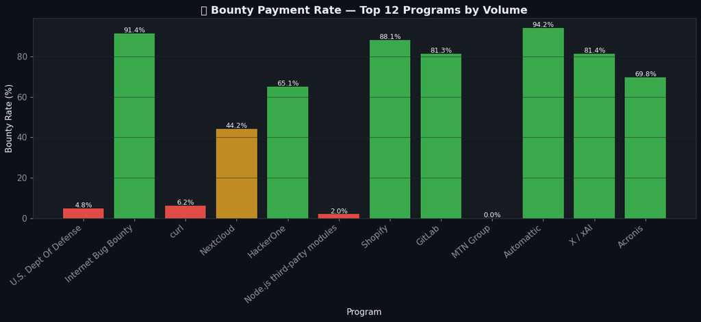

```python
# ── Plot 8 · Bounty rate by top programs ─────────────────────────────────────
prog_stats = (df.groupby("team_name")
              .agg(total=("id","count"), bounty=("has_bounty","sum"))
              .query("total >= 20"))
prog_stats["bounty_rate"] = prog_stats["bounty"] / prog_stats["total"] * 100
top_prog = prog_stats.nlargest(12, "total")

fig, ax = plt.subplots(figsize=(13, 6))
colors_bp = [GREEN if r >= 50 else YELLOW if r >= 20 else RED
             for r in top_prog["bounty_rate"]]
bars = ax.bar(top_prog.index, top_prog["bounty_rate"], color=colors_bp, alpha=0.9)
for b in bars:
    ax.text(b.get_x() + b.get_width()/2, b.get_height() + 0.5,
            f"{b.get_height():.1f}%", ha="center", fontsize=9)
ax.set_ylabel("Bounty Rate (%)"); ax.set_xlabel("Program")
ax.set_title("💵 Bounty Payment Rate — Top 12 Programs by Volume",
             fontsize=14, fontweight="bold")
plt.xticks(rotation=40, ha="right"); ax.grid(axis="y")
plt.tight_layout(); plt.show()
```

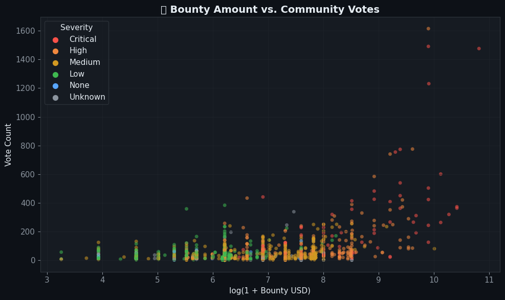

```python
# ── Plot 9 · Bounty amount vs community votes (scatter) ──────────────────────
sc = df[df["bounty_amount"].notna() & (df["bounty_amount"] > 0)].copy()
sc["sev_color"] = sc["severity_rating"].map(SEV_COLORS).fillna("#8b949e")

fig, ax = plt.subplots(figsize=(10, 6))
ax.scatter(np.log1p(sc["bounty_amount"]), sc["vote_count"],
           c=sc["sev_color"], alpha=0.55, s=25, edgecolors="none")
for sev, col in SEV_COLORS.items():
    ax.scatter([], [], color=col, label=sev.capitalize(), s=50)
ax.set_xlabel("log(1 + Bounty USD)"); ax.set_ylabel("Vote Count")
ax.set_title("💡 Bounty Amount vs. Community Votes", fontsize=14, fontweight="bold")
ax.legend(title="Severity", loc="upper left"); ax.grid()
plt.tight_layout(); plt.show()
```

## 8. Visualisation — Weakness & Program Analysis

Which vulnerability types dominate? Which programs attract the most researchers?

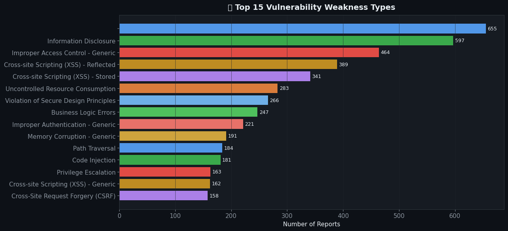

```python
# ── Plot 10 · Top 15 weakness types ──────────────────────────────────────────
top_weak = df["weakness_name"].value_counts().head(15)

fig, ax = plt.subplots(figsize=(13, 6))
colors_w = [COLORS[i % len(COLORS)] for i in range(len(top_weak))]
bars = ax.barh(top_weak.index[::-1], top_weak.values[::-1],
               color=colors_w[::-1], alpha=0.9)
for b in bars:
    ax.text(b.get_width() + 3, b.get_y() + b.get_height()/2,
            f"{int(b.get_width()):,}", va="center", fontsize=9)
ax.set_xlabel("Number of Reports")
ax.set_title("🐛 Top 15 Vulnerability Weakness Types", fontsize=14,
             fontweight="bold", pad=10)
ax.grid(axis="x"); plt.tight_layout(); plt.show()
```

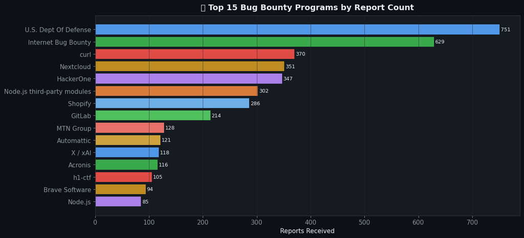

```python
# ── Plot 11 · Top 15 programs by report count ────────────────────────────────
top_teams = df["team_name"].value_counts().head(15)

fig, ax = plt.subplots(figsize=(13, 6))
colors_t  = [COLORS[i % len(COLORS)] for i in range(len(top_teams))]
bars = ax.barh(top_teams.index[::-1], top_teams.values[::-1],
               color=colors_t[::-1], alpha=0.9)
for b in bars:
    ax.text(b.get_width() + 2, b.get_y() + b.get_height()/2,
            f"{int(b.get_width()):,}", va="center", fontsize=9)
ax.set_xlabel("Reports Received")
ax.set_title("🏢 Top 15 Bug Bounty Programs by Report Count", fontsize=14,
             fontweight="bold", pad=10)
ax.grid(axis="x"); plt.tight_layout(); plt.show()
```

[figure not shown]

```python
# ── Plot 12 · Word cloud of report titles ────────────────────────────────────
STOP_EXTRA = {"the","a","an","in","of","and","or","to","for","on","with",
              "is","at","by","this","that","it","via","from","using","how"}

text = " ".join(df["title"].dropna().str.lower().tolist())
wc   = WordCloud(width=1400, height=700, background_color="#0d1117",
                 colormap="Blues", max_words=200,
                 stopwords=STOP_EXTRA).generate(text)

fig, ax = plt.subplots(figsize=(14, 7), facecolor=DARK)
ax.imshow(wc, interpolation="bilinear"); ax.axis("off")
ax.set_title("💬 Word Cloud of Report Titles", fontsize=16,
             fontweight="bold", color="#e6edf3", pad=10)
plt.tight_layout(); plt.show()
```

## 9. Visualisation — Reporter Analysis

A small cohort of prolific researchers drives a disproportionate share of all submissions — a classic power-law pattern.

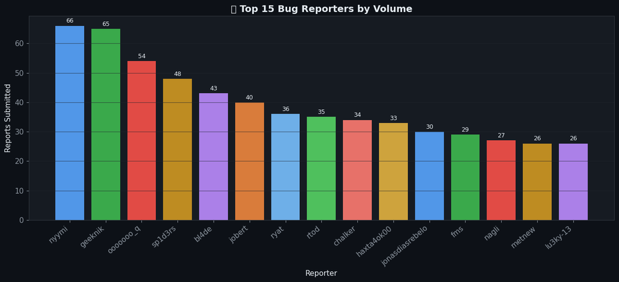

```python
# ── Plot 13 · Top 15 reporters by volume ─────────────────────────────────────
top_rep = df["reporter"].value_counts().head(15)

fig, ax = plt.subplots(figsize=(13, 6))
colors_r = [COLORS[i % len(COLORS)] for i in range(len(top_rep))]
bars = ax.bar(top_rep.index, top_rep.values, color=colors_r, alpha=0.9)
for b in bars:
    ax.text(b.get_x() + b.get_width()/2, b.get_height() + 1,
            str(int(b.get_height())), ha="center", fontsize=9)
ax.set_xlabel("Reporter"); ax.set_ylabel("Reports Submitted")
ax.set_title("🏆 Top 15 Bug Reporters by Volume", fontsize=14, fontweight="bold")
plt.xticks(rotation=40, ha="right"); ax.grid(axis="y")
plt.tight_layout(); plt.show()
```

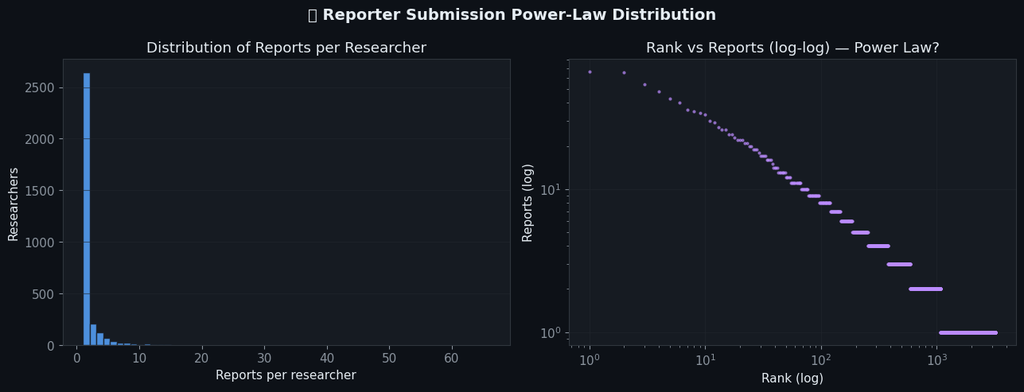

```python
# ── Plot 14 · Reporter submissions — power-law check ─────────────────────────
rep_counts = df["reporter"].value_counts()

fig, (ax1, ax2) = plt.subplots(1, 2, figsize=(13, 5))

ax1.hist(rep_counts.values, bins=60, color=ACCENT, alpha=0.85, edgecolor=CARD)
ax1.set_xlabel("Reports per researcher"); ax1.set_ylabel("Researchers")
ax1.set_title("Distribution of Reports per Researcher"); ax1.grid(axis="y")

ax2.loglog(np.arange(1, len(rep_counts)+1), rep_counts.values,
           ".", color=PURPLE, alpha=0.6, ms=4)
ax2.set_xlabel("Rank (log)"); ax2.set_ylabel("Reports (log)")
ax2.set_title("Rank vs Reports (log-log) — Power Law?"); ax2.grid()

fig.suptitle("📉 Reporter Submission Power-Law Distribution",
             fontsize=14, fontweight="bold")
plt.tight_layout(); plt.show()
```

```python
# ── Cleared vs uncleared reporter stats ──────────────────────────────────────
cleared_stats = df.groupby("reporter_cleared").agg(
    reports       = ("id",            "count"),
    avg_votes     = ("vote_count",    "mean"),
    bounty_rate   = ("has_bounty",    "mean"),
    avg_bounty    = ("bounty_amount", "mean"),
).round(2)
cleared_stats.index = ["Not Cleared", "Cleared"]
print("Reporter Cleared vs Not Cleared:")
print(cleared_stats.to_string())
```

```
Reporter Cleared vs Not Cleared:
             reports  avg_votes  bounty_rate  avg_bounty
Not Cleared     5681      32.54         0.41     1480.35
Cleared         1195      58.14         0.55     2831.48
```

## 10. Visualisation — Disclosure & Community Engagement

Disclosure timelines and community votes reveal how the platform and programs behave in terms of transparency and researcher recognition.

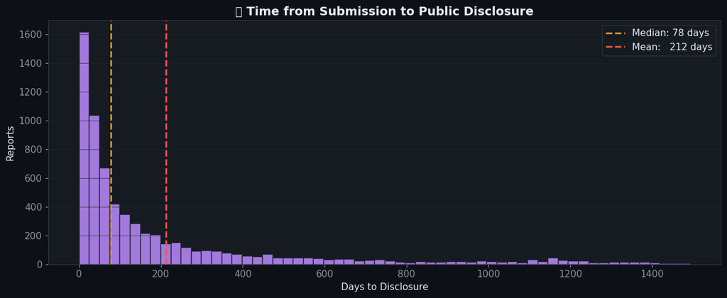

```python
# ── Plot 15 · Time from submission to disclosure ──────────────────────────────
disc = df["disclosure_days"].dropna()
disc = disc[(disc >= 0) & (disc < 1500)]

fig, ax = plt.subplots(figsize=(12, 5))
ax.hist(disc, bins=60, color=PURPLE, alpha=0.85, edgecolor=CARD)
ax.axvline(disc.median(), color=YELLOW, lw=2, ls="--",
           label=f"Median: {disc.median():.0f} days")
ax.axvline(disc.mean(),   color=RED,    lw=2, ls="--",
           label=f"Mean:   {disc.mean():.0f} days")
ax.set_xlabel("Days to Disclosure"); ax.set_ylabel("Reports")
ax.set_title("⏱️ Time from Submission to Public Disclosure",
             fontsize=14, fontweight="bold")
ax.legend(); ax.grid(axis="y"); plt.tight_layout(); plt.show()
```

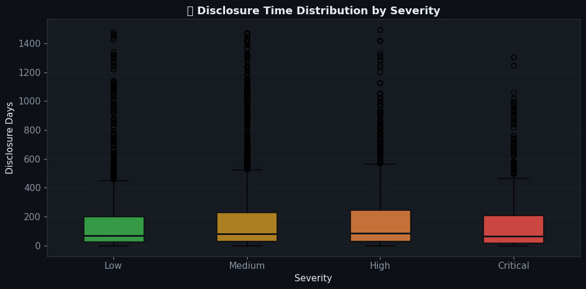

```python
# ── Plot 16 · Disclosure time by severity (box plot) ─────────────────────────
disc_sev = (df[df["severity_rating"].isin(["low","medium","high","critical"])]
            .copy())
disc_sev = disc_sev[disc_sev["disclosure_days"].between(0, 1500)]

fig, ax = plt.subplots(figsize=(10, 5))
groups   = [disc_sev[disc_sev["severity_rating"] == s]["disclosure_days"].dropna()
            for s in ["low","medium","high","critical"]]
bp = ax.boxplot(groups, patch_artist=True, notch=False,
                medianprops={"color": DARK, "lw": 2})
for patch, sev in zip(bp["boxes"], ["low","medium","high","critical"]):
    patch.set_facecolor(SEV_COLORS[sev]); patch.set_alpha(0.8)
ax.set_xticklabels(["Low","Medium","High","Critical"])
ax.set_ylabel("Disclosure Days"); ax.set_xlabel("Severity")
ax.set_title("⏳ Disclosure Time Distribution by Severity",
             fontsize=13, fontweight="bold")
ax.grid(axis="y"); plt.tight_layout(); plt.show()
```

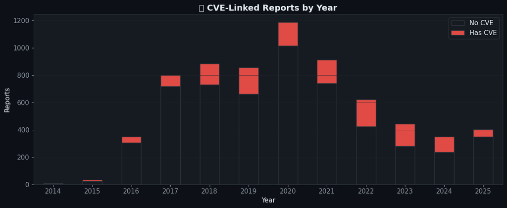

```python
# ── Plot 17 · CVE-linked reports by year ─────────────────────────────────────
cve_yr = (df[df["created_year"].between(2014, 2025)]
          .groupby(["created_year","has_cve"])
          .size()
          .unstack(fill_value=0))
cve_yr.columns = ["No CVE", "Has CVE"]

fig, ax = plt.subplots(figsize=(12, 5))
cve_yr.plot(kind="bar", stacked=True, ax=ax,
            color=[CARD, RED], edgecolor="#30363d", alpha=0.9)
ax.set_xlabel("Year"); ax.set_ylabel("Reports")
ax.set_title("🔗 CVE-Linked Reports by Year", fontsize=14, fontweight="bold")
ax.legend(); ax.grid(axis="y"); plt.xticks(rotation=0)
plt.tight_layout(); plt.show()
```

## 11. Visualisation — Advanced / Cross-Feature Analysis

Cross-feature plots, correlation analysis, AI submission trends and the summary dashboard.

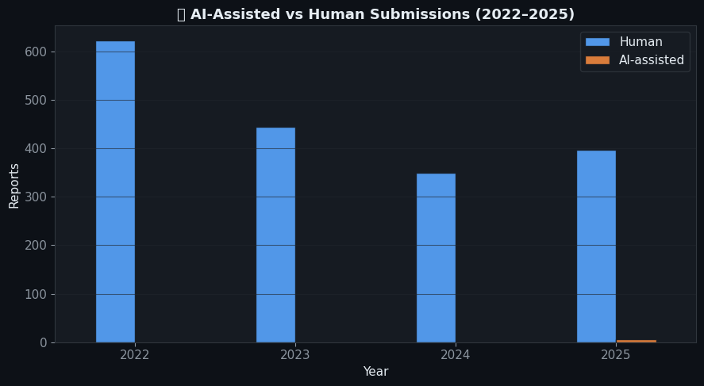

```python
# ── Plot 18 · AI-assisted vs human submissions (2022–2025) ──────────────────
ai = (df[df["created_year"].between(2022, 2025)]
      .groupby(["created_year","submitted_with_ai"])
      .size()
      .unstack(fill_value=0))
ai.columns = ["Human", "AI-assisted"]

fig, ax = plt.subplots(figsize=(9, 5))
ai.plot(kind="bar", ax=ax, color=[ACCENT, ORANGE], alpha=0.9, edgecolor=CARD)
ax.set_xlabel("Year"); ax.set_ylabel("Reports")
ax.set_title("🤖 AI-Assisted vs Human Submissions (2022–2025)",
             fontsize=13, fontweight="bold")
ax.legend(); ax.grid(axis="y"); plt.xticks(rotation=0)
plt.tight_layout(); plt.show()
```

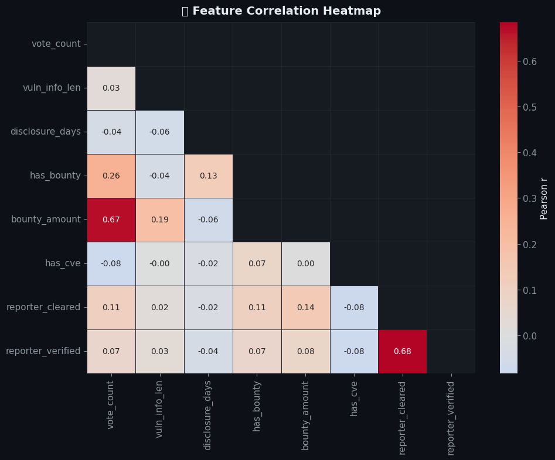

```python
# ── Plot 19 · Feature correlation heatmap ────────────────────────────────────
num_cols = ["vote_count","vuln_info_len","disclosure_days",
            "has_bounty","bounty_amount","has_cve",
            "reporter_cleared","reporter_verified"]
corr = df[num_cols].apply(pd.to_numeric, errors="coerce").corr()

fig, ax = plt.subplots(figsize=(10, 8))
mask = np.triu(np.ones_like(corr, dtype=bool))
sns.heatmap(corr, ax=ax, mask=mask, annot=True, fmt=".2f",
            cmap="coolwarm", center=0,
            linewidths=0.5, linecolor="#21262d",
            cbar_kws={"label": "Pearson r"},
            annot_kws={"size": 10})
ax.set_title("🔥 Feature Correlation Heatmap", fontsize=14,
             fontweight="bold", pad=10)
plt.tight_layout(); plt.show()
```

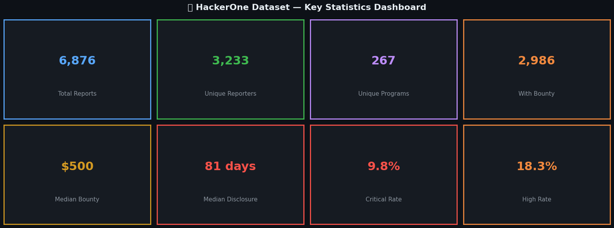

```python
# ── Plot 20 · Summary KPI dashboard ──────────────────────────────────────────
total     = len(df)
w_bounty  = int(df["has_bounty"].sum())
med_bount = df["bounty_amount"].median()
uniq_rep  = df["reporter"].nunique()
uniq_prg  = df["team_name"].nunique()
med_disc  = df["disclosure_days"].median()
pct_crit  = (df["severity_rating"] == "critical").mean() * 100
pct_high  = (df["severity_rating"] == "high").mean()    * 100

kpis = [
    ("Total Reports",     f"{total:,}",            ACCENT),
    ("Unique Reporters",  f"{uniq_rep:,}",          GREEN),
    ("Unique Programs",   f"{uniq_prg:,}",          PURPLE),
    ("With Bounty",       f"{w_bounty:,}",          ORANGE),
    ("Median Bounty",
     f"${med_bount:,.0f}" if not np.isnan(med_bount) else "N/A", YELLOW),
    ("Median Disclosure",
     f"{med_disc:.0f} days" if not np.isnan(med_disc) else "N/A", RED),
    ("Critical Rate",     f"{pct_crit:.1f}%",       RED),
    ("High Rate",         f"{pct_high:.1f}%",       ORANGE),
]

fig, axes = plt.subplots(2, 4, figsize=(16, 6), facecolor=DARK)
for ax, (label, val, col) in zip(axes.flat, kpis):
    ax.set_facecolor(CARD)
    ax.text(0.5, 0.58, val, ha="center", va="center",
            fontsize=22, fontweight="bold", color=col, transform=ax.transAxes)
    ax.text(0.5, 0.25, label, ha="center", va="center",
            fontsize=11, color="#8b949e", transform=ax.transAxes)
    for sp in ax.spines.values():
        sp.set_edgecolor(col); sp.set_linewidth(2)
    ax.set_xticks([]); ax.set_yticks([])

fig.suptitle("📊 HackerOne Dataset — Key Statistics Dashboard",
             fontsize=16, fontweight="bold", color="#e6edf3")
plt.tight_layout(); plt.show()
```

```python
# ── Statistical test: do cleared reporters earn more bounty? ─────────────────
cleared   = df[df["reporter_cleared"]  & df["bounty_amount"].notna()]["bounty_amount"]
uncleared = df[~df["reporter_cleared"] & df["bounty_amount"].notna()]["bounty_amount"]

stat, p = stats.mannwhitneyu(cleared, uncleared, alternative="two-sided")
print(f"Mann-Whitney U test — Cleared vs Un-cleared reporters on bounty amount")
print(f"  U-statistic : {stat:,.0f}")
print(f"  p-value     : {p:.4f}")
print(f"  Cleared   median bounty: ${cleared.median():,.2f}  (n={len(cleared):,})")
print(f"  Uncleared median bounty: ${uncleared.median():,.2f}  (n={len(uncleared):,})")
if p < 0.05:
    print("  → Statistically significant difference (α=0.05)")
else:
    print("  → No statistically significant difference (α=0.05)")
```

```
Mann-Whitney U test — Cleared vs Un-cleared reporters on bounty amount
  U-statistic : 113,746
  p-value     : 0.0678
  Cleared   median bounty: $560.00  (n=192)
  Uncleared median bounty: $500.00  (n=1,095)
  → No statistically significant difference (α=0.05)
```

## 12. Save Cleaned Dataset

We serialise the cleaned, enriched DataFrame to a single CSV file for downstream use.  
List-type columns (`cve_ids`) are joined with `;` for CSV compatibility.

```python
# ── Serialise list columns & export ──────────────────────────────────────────
df_out = df.copy()
df_out["cve_ids"] = df_out["cve_ids"].apply(
    lambda x: ";".join(x) if isinstance(x, list) else "")

OUTPUT_PATH = "./hackerone_cleaned.csv"
df_out.to_csv(OUTPUT_PATH, index=False)
print(f"✅ Saved {len(df_out):,} rows × {len(df_out.columns)} columns → {OUTPUT_PATH}")
```

```
✅ Saved 6,876 rows × 29 columns → ./hackerone_cleaned.csv
```

```python
# ── Quick sanity check on the saved file ─────────────────────────────────────
check = pd.read_csv(OUTPUT_PATH)
print(f"Re-loaded shape : {check.shape}")
print(f"Columns         : {list(check.columns)}")
check.head(3)
```

```
Re-loaded shape : (6876, 29)
Columns         : ['id', 'title', 'state', 'substate', 'severity_rating', 'has_bounty', 'bounty_amount', 'vote_count', 'created_at', 'submitted_at', 'disclosed_at', 'reporter', 'reporter_cleared', 'reporter_verified', 'team_handle', 'team_name', 'offers_bounties', 'weakness_name', 'weakness_id', 'cv…
```

|  | id | title | state | substate | severity_rating | has_bounty | bounty_amount | vote_count | created_at | submitted_at | ... | cve_ids | has_cve | public | submitted_with_ai | vuln_info_len | _year_folder | created_year | created_month | created_dow | disclosure_days |
| --- | --- | --- | --- | --- | --- | --- | --- | --- | --- | --- | --- | --- | --- | --- | --- | --- | --- | --- | --- | --- | --- |
| 0 | 11073 | XSS in gist integration | Closed | resolved | unknown | True | 500.0 | 156 | 2014-05-06 18:21:27.236000+00:00 | 2014-05-06 18:21:27.236000+00:00 | ... | NaN | False | True | False | 262 | 2014 | 2014 | 5 | 1 | 1817 |
| 1 | 16910 | Cross-site information assertion leak via Cont... | Closed | resolved | unknown | False | NaN | 13 | 2014-06-18 22:31:04.534000+00:00 | 2014-06-18 22:31:04.534000+00:00 | ... | NaN | False | True | False | 4323 | 2014 | 2014 | 6 | 2 | 1539 |
| 2 | 18843 | use-after-free vulnerability in Flash Player | Closed | resolved | unknown | True | NaN | 1 | 2014-07-03 05:06:17.257000+00:00 | 2014-07-03 05:06:17.257000+00:00 | ... | NaN | False | True | False | 6175 | 2014 | 2014 | 7 | 3 | 1958 |

3 rows × 29 columns

## 13. Key Findings Summary

[output not shown]

> **Next steps:** NLP on `vulnerability_information`, time-series forecasting of submission volume, or building a severity predictor using weakness + program features.